# Visualization of Multivariate Data

23 Feb 2021 (*updated: 2021-02-23)*

## i. Admin & Startup

## Schedule review

- Let’s review the schedule and place today’s learning in context.
- Please complete the **midterm exam** and Ch. 4 Problem Set by Friday.
- Questions regarding Ch. 4 HW?
- Clarification questions for the midterm exam?

## Today’s plan

I. Preview Ch. 5 Problem Set questions to prime learning.  
II. Discuss Ch. 5  
III. Revisit Ch. 5 Problem prompt discussion / hints

*Please contribute questions and comments*

## I. Preview Ch.5 Problem Set

- 5.3-5.6 Two-component mixture viz (vary the mixing parameter)
- 5.7 (parallel coordinates)
- 5.11 (segment-style stars plot)
- 5.12, 5.13 Understanding PCA
- 5.16 Applying PCA

## II. Chapter 5 discussion

## 5.1 Introduction

- Importance of viz for exploratory data analysis (EDA).
- The term “exploratory” is in contrast to “confirmatory,” which could describe hypothesis testing.
- Tukeybelieved that it was important to do the exploratory work before hypothesis testing, to learn what are the appropriate questions to ask, and the most appropriate methods to answer them.
- With multivariate data, we may also be interested in dimension reduction or finding structure or groups in the data. Here we restrict attention to methods for visualizing multivariate data.
- Discuss Table 5.1

## 5.3 Correlation plots

- dimension reduction
- useful for predictive modeling
- fitting considerations for highly correlated features
- Discuss Example 5.2 (Decathlon data)

## 5.4 Surface plots and 3D Scatter plots

- Discuss Example 5.3
- `expand.grid` is great for simulation configurations
- Discuss Figure 5.7 scatter plot briefly

## 5.5 Contour Plots

- briefly discuss in Rizzo.

## 5.6 Other 2D Representations of Data

## Example 5.11 (Parallel Coordinate)

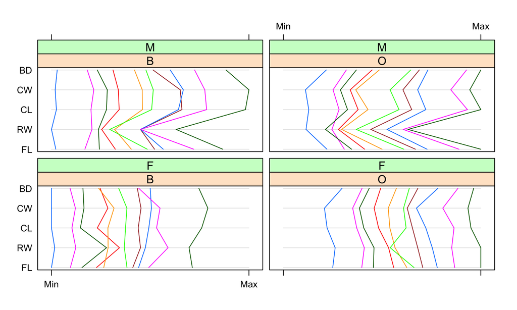

```r
library(MASS)
library(lattice)
##trellis.device(color = FALSE) #black and white display
x <- crabs[seq(5, 200, 5), ]  #get every fifth obs.
parallelplot(~x[4:8] | sp*sex, x)
```

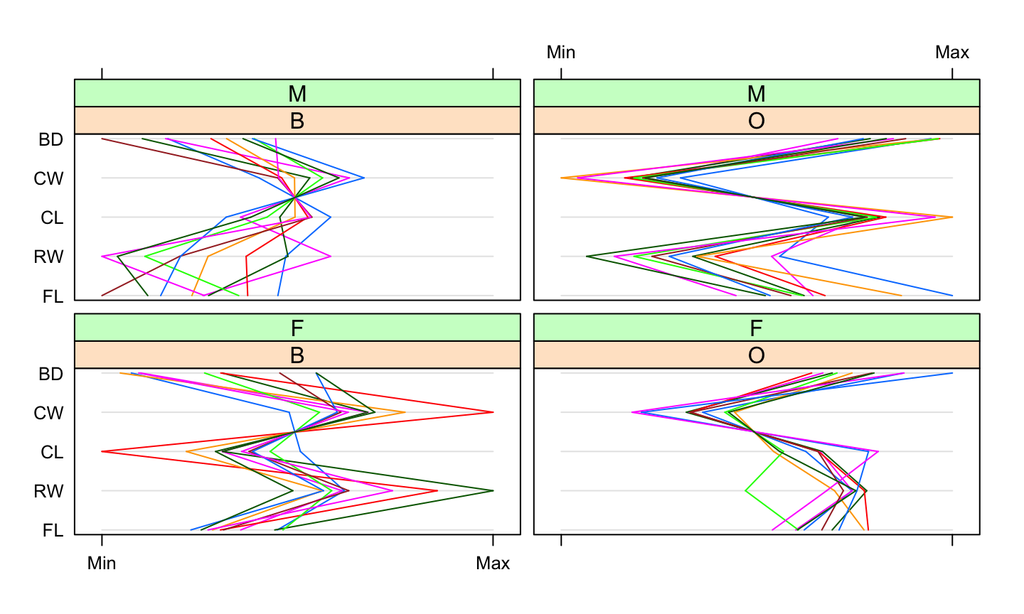

```r
##trellis.device(color = FALSE)    #black and white display
x <- crabs[seq(5, 200, 5), ]     #get every fifth obs.
a <- x$CW * x$CL                 #area of carapace
x[4:8] <- x[4:8] / sqrt(a)       #adjust for size
parallelplot(~x[4:8] | sp*sex, x)
```

## Example 5.12 (segment plot)

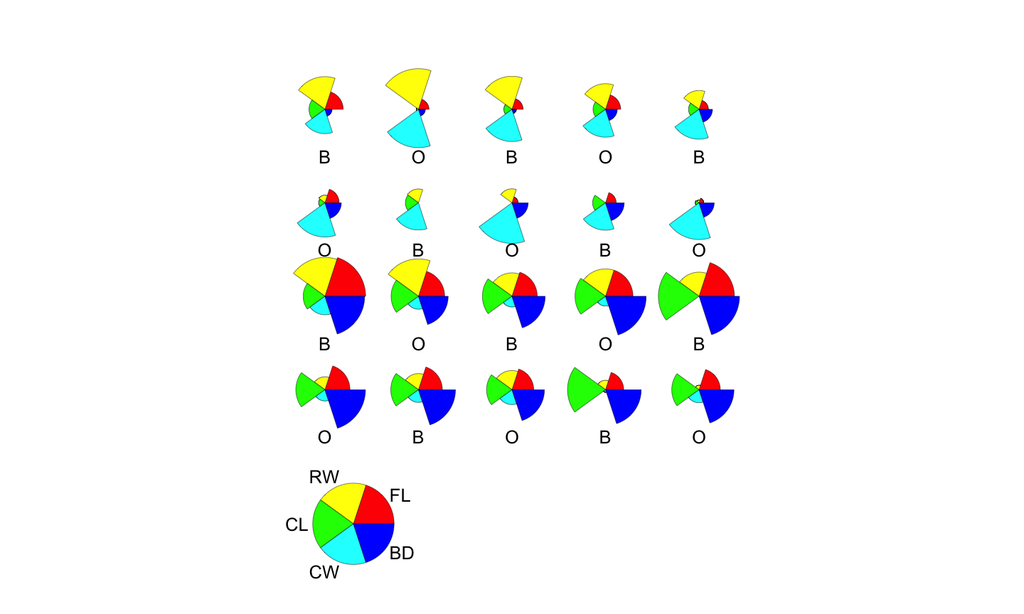

```r
x <- MASS::crabs[seq(5, 200, 5), ]         #get every fifth obs.
x <- subset(x, sex == "M")           #keep just the males
a <- x$CW * x$CL                     #area of carapace
x[4:8] <- x[4:8] / sqrt(a)           #adjust for size

palette(rainbow(6))                 #or use color
stars(x[4:8], draw.segments = TRUE,
      labels =levels(x$sp), nrow = 4,
      ylim = c(-2,10), key.loc = c(3,-1))
```

```r
palette("default")
```

## Single-cell transcriptome dysregulation viz

Schissler AG, Li Q, Chen JL, Kenost C, Achour I, Billheimer DD, Li H, Piegorsch WW, Lussier YA. *Analysis of aggregated cell-cell statistical distances within pathways unveils therapeutic-resistance mechanisms in circulating tumor cells. Bioinformatics.* 2016 Jun 15;32(12):i80-i89. doi: 10.1093/bioinformatics/btw248. PMID: 27307648; PMCID: PMC4908332. https://www.ncbi.nlm.nih.gov/pmc/articles/PMC4908332/

- `nof1` pathways R package vignette: http://www.lussierlab.net//publications/nof1pathways-vignette_v2.html

Ask me if you want the code, it is under patent.

## 5.7 Principal Component Analysis (PCA)

## 2D PCA illustration

https://en.wikipedia.org/wiki/Principal_component_analysis#/media/File:GaussianScatterPCA.svg

## Example 5.13 (PCA)

```r
library(bootstrap)
str(scor)
```

```
## 'data.frame':    88 obs. of  5 variables:
##  $ mec: num  77 63 75 55 63 53 51 59 62 64 ...
##  $ vec: num  82 78 73 72 63 61 67 70 60 72 ...
##  $ alg: num  67 80 71 63 65 72 65 68 58 60 ...
##  $ ana: num  67 70 66 70 70 64 65 62 62 62 ...
##  $ sta: num  81 81 81 68 63 73 68 56 70 45 ...
```

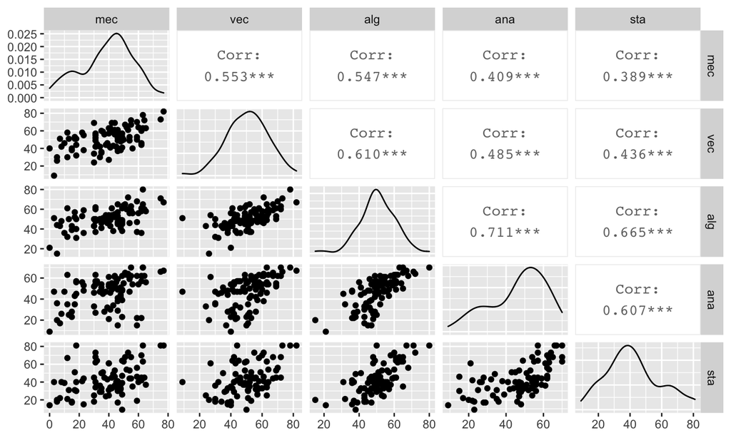

```r
library(GGally)
plot513b <- ggpairs(scor)
plot513b
```

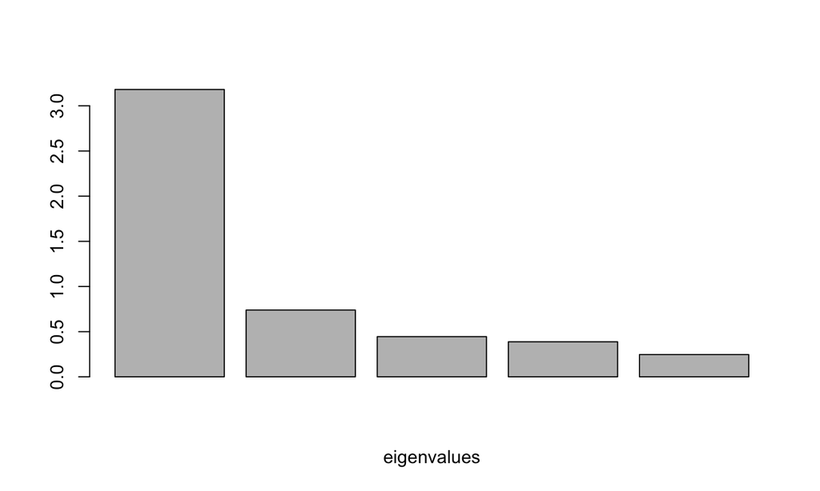

```r
n <- nrow(scor)
x <- scale(scor)  #center and scale
s <- cov(x)
e <- eigen(s)
lam <- e$values   #vector of eigenvalues
P <- e$vectors    #matrix of eigenvectors
## plot(lam, type = "b", xlab = "eigenvalues", main = "")
barplot(lam, xlab = "eigenvalues")
```

```r
tab <- rbind(lam / sum(lam), cumsum(lam) / sum(lam))
tab
```

| 0.636196 | 0.1479144 | 0.0889930 | 0.0775785 | 0.0493181 |
| --- | --- | --- | --- | --- |
| 0.636196 | 0.7841104 | 0.8731034 | 0.9506819 | 1.0000000 |

```r
z <- x %*% P
dim(z)
```

```
## [1] 88  5
```

```r
head(z)
```

| -4.285041 | 0.6741023 | 0.1235891 | 0.7931108 | -0.5143803 |
| --- | --- | --- | --- | --- |
| -4.541989 | -0.2133118 | -0.2317797 | 0.5516063 | 0.5961897 |
| -4.102690 | 0.2755753 | 0.5304377 | 0.6096862 | -0.0278160 |
| -3.026846 | -0.1491621 | -0.3702154 | 0.1595890 | -0.4395048 |
| -2.882081 | -0.0440801 | 0.2988861 | -0.3225740 | -0.1476779 |
| -2.988775 | -0.6812620 | 0.2628756 | 0.2950331 | 0.5475449 |

```r
pc <- prcomp(scor, center = TRUE, scale = TRUE)
summary(pc)
```

```
## Importance of components:
##                           PC1    PC2     PC3     PC4     PC5
## Standard deviation     1.7835 0.8600 0.66706 0.62281 0.49658
## Proportion of Variance 0.6362 0.1479 0.08899 0.07758 0.04932
## Cumulative Proportion  0.6362 0.7841 0.87310 0.95068 1.00000
```

```r
df <- scor[1:5, ]
predict(pc, newdata = df)  #same as z above
```

| PC1 | PC2 | PC3 | PC4 | PC5 |
| --- | --- | --- | --- | --- |
| -4.285041 | -0.6741023 | 0.1235891 | 0.7931108 | -0.5143803 |
| -4.541989 | 0.2133118 | -0.2317797 | 0.5516063 | 0.5961897 |
| -4.102690 | -0.2755753 | 0.5304377 | 0.6096862 | -0.0278160 |
| -3.026846 | 0.1491621 | -0.3702154 | 0.1595890 | -0.4395048 |
| -2.882081 | 0.0440801 | 0.2988861 | -0.3225740 | -0.1476779 |

```r
head(x %*% pc$rotation, 5)
```

| PC1 | PC2 | PC3 | PC4 | PC5 |
| --- | --- | --- | --- | --- |
| -4.285041 | -0.6741023 | 0.1235891 | 0.7931108 | -0.5143803 |
| -4.541989 | 0.2133118 | -0.2317797 | 0.5516063 | 0.5961897 |
| -4.102690 | -0.2755753 | 0.5304377 | 0.6096862 | -0.0278160 |
| -3.026846 | 0.1491621 | -0.3702154 | 0.1595890 | -0.4395048 |
| -2.882081 | 0.0440801 | 0.2988861 | -0.3225740 | -0.1476779 |

```r
head(pc$rotation)
```

|  | PC1 | PC2 | PC3 | PC4 | PC5 |
| --- | --- | --- | --- | --- | --- |
| mec | -0.3996045 | -0.6454583 | 0.6207825 | -0.1457865 | -0.1306722 |
| vec | -0.4314191 | -0.4415053 | -0.7050063 | 0.2981351 | -0.1817479 |
| alg | -0.5032816 | 0.1290675 | -0.0370490 | -0.1085987 | 0.8466894 |
| ana | -0.4569938 | 0.3879057 | -0.1361818 | -0.6662561 | -0.4221885 |
| sta | -0.4382444 | 0.4704545 | 0.3125334 | 0.6589164 | -0.2340223 |

```r
head(P)
```

| -0.3996045 | 0.6454583 | 0.6207825 | -0.1457865 | -0.1306722 |
| --- | --- | --- | --- | --- |
| -0.4314191 | 0.4415053 | -0.7050063 | 0.2981351 | -0.1817479 |
| -0.5032816 | -0.1290675 | -0.0370490 | -0.1085987 | 0.8466894 |
| -0.4569938 | -0.3879057 | -0.1361818 | -0.6662561 | -0.4221885 |
| -0.4382444 | -0.4704545 | 0.3125334 | 0.6589164 | -0.2340223 |

## Example 5.14 (PC Biplot)

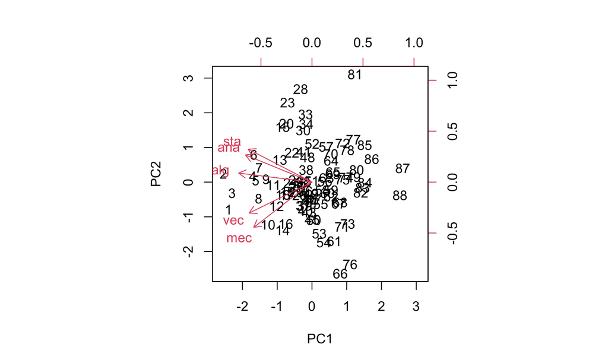

```r
## plot scor data in the (PC1, PC2) coordinate system
biplot(pc, pc.biplot = TRUE)
```

```r
round(cor(x, z), 3)
```

| mec | -0.713 | 0.555 | 0.414 | -0.091 | -0.065 |
| --- | --- | --- | --- | --- | --- |
| vec | -0.769 | 0.380 | -0.470 | 0.186 | -0.090 |
| alg | -0.898 | -0.111 | -0.025 | -0.068 | 0.420 |
| ana | -0.815 | -0.334 | -0.091 | -0.415 | -0.210 |
| sta | -0.782 | -0.405 | 0.208 | 0.410 | -0.116 |

## Example 5.15 ( Decathlon PCA)

### Example 5.15 (PCA: Decathlon data)

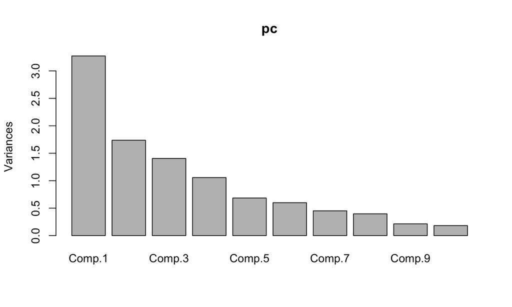

```r
library(FactoMineR)
data(decathlon)
pc <- princomp(decathlon[,1:10], cor = TRUE, scores = TRUE)
plot(pc)     # screeplot
```

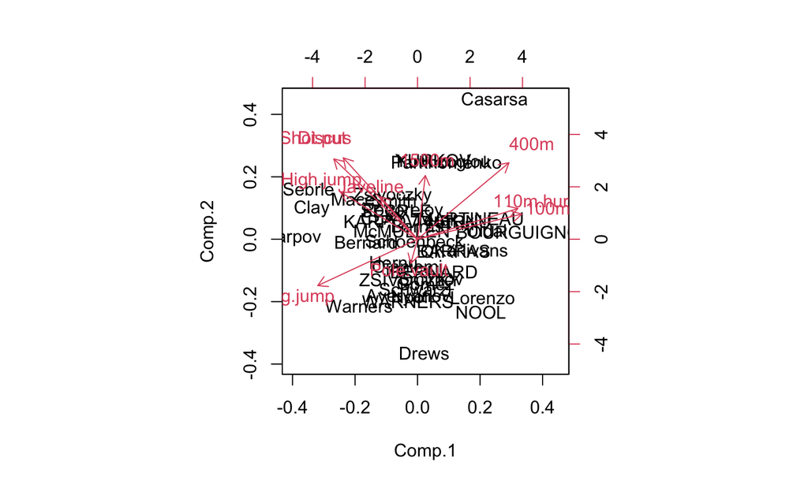

```r
biplot(pc)
```

```r
summary(pc)
```

```
## Importance of components:
##                           Comp.1    Comp.2    Comp.3    Comp.4     Comp.5
## Standard deviation     1.8088409 1.3180027 1.1852918 1.0280323 0.82751044
## Proportion of Variance 0.3271906 0.1737131 0.1404917 0.1056850 0.06847735
## Cumulative Proportion  0.3271906 0.5009037 0.6413953 0.7470804 0.81555771
##                            Comp.6     Comp.7     Comp.8     Comp.9    Comp.10
## Standard deviation     0.77412446 0.67174047 0.62998142 0.46348123 0.42688111
## Proportion of Variance 0.05992687 0.04512353 0.03968766 0.02148149 0.01822275
## Cumulative Proportion  0.87548458 0.92060811 0.96029577 0.98177725 1.00000000
```

## 5.8 Other approaches to Data Visualization

- interesting content such as *grand tour* viz via `tourr` package.
- `FactoMineR` for multivariate viz
- https://datavis.ca/ categorical data
- `forcats` in tidyverse

## 5.9 Additional resources

Good list of resources. Check them out for inspiration during when developing your next important plot.

## Closing

- Students please summarize/ask questions about what we discussed today.
- Other questions?